# Logistic Regression

Cody Frisby

April 2, 2016

### DONNER PARTY

| Variable | Description |
| --- | --- |
| age | Age of individual |
| sex | 1 – male, 0 - female |
| survive | 1 – survived, 0 - died |

#### RQ1: What is the relationship between survival and gender?

#### RQ2: Predict the probability of survival as a function of age.

#### RQ3: After taking into account age, are women more likely to survive harsh conditions than men?

First, we get the data into R and take a look at some summarys.

```r
don <- read.table("~/Documents/MATH3710/donnerparty/donner.txt")
names(don) <- c("age", "sex", "survive")
summary(don) # look at a summary of the data frame
```

```
##       age            sex            survive
##  Min.   :15.0   Min.   :0.0000   Min.   :0.0000
##  1st Qu.:24.0   1st Qu.:0.0000   1st Qu.:0.0000
##  Median :28.0   Median :1.0000   Median :0.0000
##  Mean   :31.8   Mean   :0.6667   Mean   :0.4444
##  3rd Qu.:40.0   3rd Qu.:1.0000   3rd Qu.:1.0000
##  Max.   :65.0   Max.   :1.0000   Max.   :1.0000
```

```r
attach(don) # this "attaches" the data frame to our session
table(sex, survive) # table of sex vs. survive
```

```
##    survive
## sex  0  1
##   0  5 10
##   1 20 10
```

```r
tmp <- chisq.test(sex, survive, correct = F)
# chi square test for the same
tmp$expected
```

```
##    survive
## sex         0         1
##   0  8.333333  6.666667
##   1 16.666667 13.333333
```

```r
tmp
```

```
##
##  Pearson's Chi-squared test
##
## data:  sex and survive
## X-squared = 4.5, df = 1, p-value = 0.03389
```

## Start Logistic Regression

The logistic regression function is $\pi(x) = P[Y = 1 | X = x] = \frac{e^{\beta_0 + \beta_1x}}{1 + e^{\beta_0 + \beta_1x}}$ and is NOT linear.  
Here we fit the donner data to a logistic model using R.

```r
fit <- glm(survive ~ age, family = binomial(), data = don)
summary(fit)$coef # betas
```

```
##                Estimate Std. Error   z value   Pr(>|z|)
## (Intercept)  1.81851831 0.99937233  1.819660 0.06881073
## age         -0.06647028 0.03222003 -2.063011 0.03911155
```

```r
# or
#anova(fit, test = "Chisq")
# use our model to predict
age <- c(10,20,30,40,50,60)
# odds ratio
exp(predict(fit, data.frame(age)))
```

```
##         1         2         3         4         5         6
## 3.1702660 1.6308685 0.8389618 0.4315841 0.2220183 0.1142121
```

```r
odds <- exp(predict(fit, data.frame(age)))
p <- odds/(1+odds)
# odds go down with age.
knitr::kable(cbind(age,odds,p))
```

| age | odds | p |
| --- | --- | --- |
| 10 | 3.1702660 | 0.7602071 |
| 20 | 1.6308685 | 0.6198974 |
| 30 | 0.8389618 | 0.4562149 |
| 40 | 0.4315841 | 0.3014731 |
| 50 | 0.2220183 | 0.1816816 |
| 60 | 0.1142121 | 0.1025048 |

Look at a plot of the predicted values vs. age

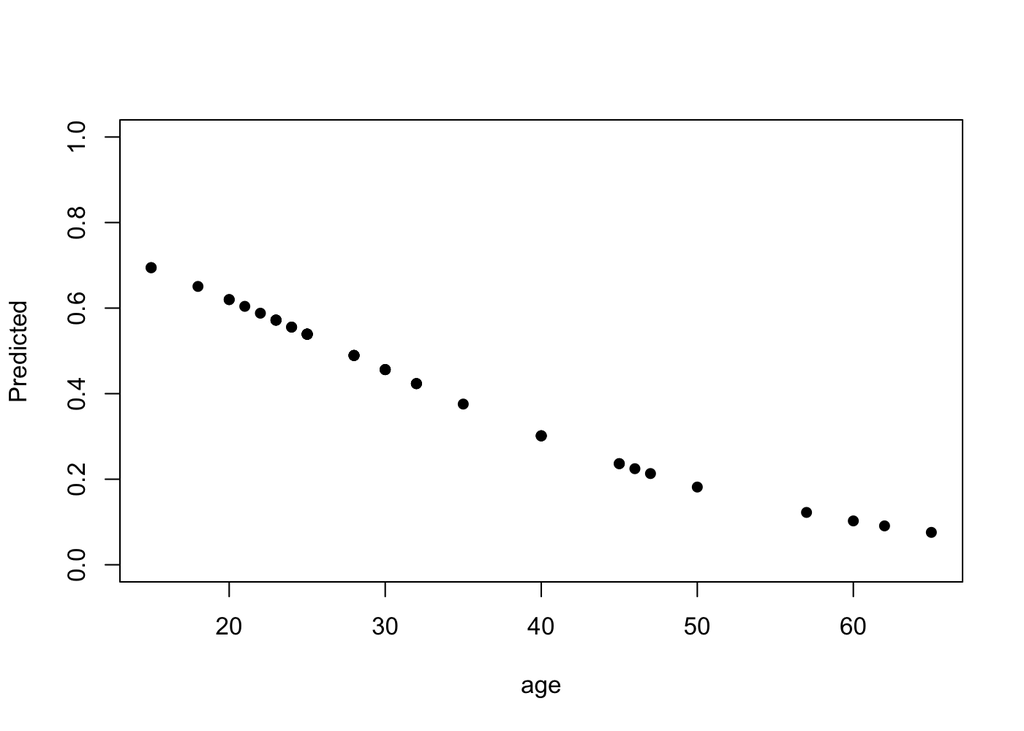

```r
plot(don$age, fit$fitted.values, ylab = "Predicted", xlab = "age",
     pch=16, ylim = c(0,1))
```

And to see the odds Ratio:

```r
exp(summary(fit)$coef) # odds ratio
```

```
##              Estimate Std. Error   z value Pr(>|z|)
## (Intercept) 6.1627204   2.716576 6.1697632 1.071233
## age         0.9356907   1.032745 0.1270707 1.039886
```

```r
exp(confint(fit)) #confidence interval
```

```
##                 2.5 %     97.5 %
## (Intercept) 0.9940306 54.0635442
## age         0.8695861  0.9898905
```

So the logit model can be written as $ln(\frac{\pi}{1 - \pi}) = \beta_0 + \beta_1x_1 + ... + \beta_kx_k$

Notes:  
1. The logarithm of the odds ratio is called a logit.  
2. $0 \leq \pi \leq 1$ but $- \infty < ln(\frac{\pi}{1 - \pi}) < \infty$ which makes the logit more appropriate for an unbounded linear function.  
We use MLE (maximum liklihood estimation) to estimate the values for $\beta_i$.

## Playing around with the class notes and R functions.

This is the logistic regression function shared in class and in the notes.

```r
# here we define a function
logit <- function(x){
  -2*log(2) + log(2)*x
}
# here we use the function above on some inputs
gpa <- c(0,1,2,3,4)
logit(gpa)
```

```
## [1] -1.3862944 -0.6931472  0.0000000  0.6931472  1.3862944
```

```r
# and we raise this here to get the odds
exp(logit(gpa))
```

```
## [1] 0.25 0.50 1.00 2.00 4.00
```

```r
odds <- exp(logit(gpa))
# and to go back to probabilities
odds/(1+odds)
```

```
## [1] 0.2000000 0.3333333 0.5000000 0.6666667 0.8000000
```

```r
p <- odds/(1+odds)
knitr::kable(cbind(gpa,odds,p))
```

| gpa | odds | p |
| --- | --- | --- |
| 0 | 0.25 | 0.2000000 |
| 1 | 0.50 | 0.3333333 |
| 2 | 1.00 | 0.5000000 |
| 3 | 2.00 | 0.6666667 |
| 4 | 4.00 | 0.8000000 |

Here’s how you would do a table of the values using R. Remeber, we have already attached the data frame donner.

```r
with(don, table(age, survive))
```

```
##     survive
## age  0 1
##   15 1 1
##   18 0 1
##   20 0 2
##   21 0 1
##   22 0 1
##   23 2 2
##   24 1 1
##   25 6 2
##   28 2 2
##   30 3 1
##   32 0 3
##   35 1 0
##   40 1 2
##   45 2 0
##   46 0 1
##   47 1 0
##   50 1 0
##   57 1 0
##   60 1 0
##   62 1 0
##   65 1 0
```

```r
with(don, chisq.test(age, survive))
```

```
##
##  Pearson's Chi-squared test
##
## data:  age and survive
## X-squared = 21.038, df = 20, p-value = 0.3949
```

```r
fit2 <- glm(survive ~ age+sex, family = binomial(link = "logit"),
            data = don)
summary(fit2)
```

```
##
## Call:
## glm(formula = survive ~ age + sex, family = binomial(link = "logit"),
##     data = don)
##
## Deviance Residuals:
##     Min       1Q   Median       3Q      Max
## -1.7445  -1.0441  -0.3029   0.8877   2.0472
##
## Coefficients:
##             Estimate Std. Error z value Pr(>|z|)
## (Intercept)  3.23041    1.38686   2.329   0.0198 *
## age         -0.07820    0.03728  -2.097   0.0359 *
## sex         -1.59729    0.75547  -2.114   0.0345 *
## ---
## Signif. codes:  0 '***' 0.001 '**' 0.01 '*' 0.05 '.' 0.1 ' ' 1
##
## (Dispersion parameter for binomial family taken to be 1)
##
##     Null deviance: 61.827  on 44  degrees of freedom
## Residual deviance: 51.256  on 42  degrees of freedom
## AIC: 57.256
##
## Number of Fisher Scoring iterations: 4
```

### Performing the Hosmer - Lemeshow Goodness of Fit Test

Install the package “ResourceSelection” by typing in install.packages(“ResourceSelection”).

```r
library(ResourceSelection)
```

```
## ResourceSelection 0.2-6   2016-02-15
```

```r
hl <- hoslem.test(fit$y, fit$fitted.values, g = 8)
hl
```

```
##
##  Hosmer and Lemeshow goodness of fit (GOF) test
##
## data:  fit$y, fit$fitted.values
## X-squared = 6.3529, df = 6, p-value = 0.3848
```

```r
# we can also look at some tables
cbind(hl$observed, hl$expected)
```

```
##                y0 y1     yhat0     yhat1
## [0.0757,0.219]  6  0 5.2136098 0.7863902
## (0.219,0.301]   3  3 4.3982358 1.6017642
## (0.301,0.456]   4  4 4.5290438 3.4709562
## (0.456,0.489]   2  2 2.0426431 1.9573569
## (0.489,0.539]   6  2 3.6871178 4.3128822
## (0.539,0.556]   1  1 0.8888454 1.1111546
## (0.556,0.596]   2  3 2.1241939 2.8758061
## (0.596,0.695]   1  5 2.1163104 3.8836896
```

## Concordance

thanks to http://shashiasrblog.blogspot.com/2014/01/binary-logistic-regression-on-r.html for this function

```r
###########################################################
# Function OptimisedConc : for concordance, discordance, ties
# The function returns Concordance, discordance, and ties
# by taking a glm binomial model result as input.
# Although it still uses two-for loops, it optimises the code
# by creating initial zero matrices
###########################################################
OptimisedConc=function(model)
{
  Data = cbind(model$y, model$fitted.values)
  ones = Data[Data[,1] == 1,]
  zeros = Data[Data[,1] == 0,]
  conc=matrix(0, dim(zeros)[1], dim(ones)[1])
  disc=matrix(0, dim(zeros)[1], dim(ones)[1])
  ties=matrix(0, dim(zeros)[1], dim(ones)[1])
  for (j in 1:dim(zeros)[1])
  {
    for (i in 1:dim(ones)[1])
    {
      if (ones[i,2]>zeros[j,2])
      {conc[j,i]=1}
      else if (ones[i,2]<zeros[j,2])
      {disc[j,i]=1}
      else if (ones[i,2]==zeros[j,2])
      {ties[j,i]=1}
    }
  }
  Pairs=dim(zeros)[1]*dim(ones)[1]
  PercentConcordance=(sum(conc)/Pairs)*100
  PercentDiscordance=(sum(disc)/Pairs)*100
  PercentTied=(sum(ties)/Pairs)*100
  return(list("Percent Concordance"=PercentConcordance,"Percent Discordance"=PercentDiscordance,"Percent Tied"=PercentTied,"Pairs"=Pairs))
}
```

This function, OptimisedConc, takes one input, your logistic model and returns a list of values.

```r
OptimisedConc(fit2)
```

```
## $`Percent Concordance`
## [1] 73
##
## $`Percent Discordance`
## [1] 23.8
##
## $`Percent Tied`
## [1] 3.2
##
## $Pairs
## [1] 500
```

## ROC curves in R

Let’s install another package for this job, pROC, by calling install.packages(“pROC”).

```r
library(pROC)
roc(fit2$y, fit2$fitted.values)
```

```
##
## Call:
## roc.default(response = fit2$y, predictor = fit2$fitted.values)
##
## Data: fit2$fitted.values in 25 controls (fit2$y 0) < 20 cases (fit2$y 1).
## Area under the curve: 0.746
```

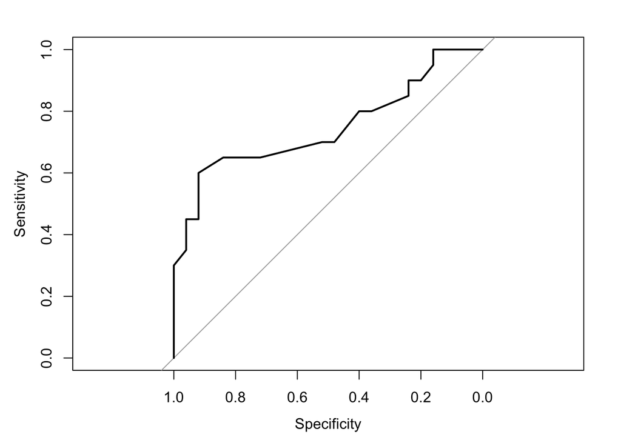

```
##
## Call:
## roc.default(response = fit2$y, predictor = fit2$fitted.values)
##
## Data: fit2$fitted.values in 25 controls (fit2$y 0) < 20 cases (fit2$y 1).
## Area under the curve: 0.746
```

```r
plot(roc(fit2$y, fit2$fitted.values))
```

```r
# this is why I love R
```

## Classification Table

We can create our own classification table using R and a logical statement for the value of pi we’d like to classify on, for example $\pi > 0.5$.

```r
theprobs <- fit$fitted.values
table(fit$y, 1*(theprobs > .5))
```

```
##
##      0  1
##   0 15 10
##   1  9 11
```

- Plot of predicted vs age by sex.

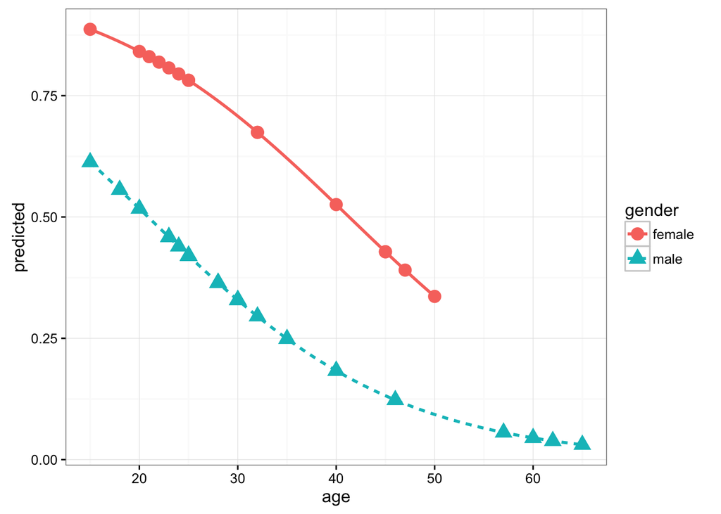

```r
# adding a new column to sore
don$gender <- 0
don$predicted <- fit2$fitted.values
don[don$sex == 1, "gender"] <- "male"
don[don$sex == 0, "gender"] <- "female"
don$gender <- factor(don$gender)
library(ggplot2) # using ggplot2 to create this plot
g <- ggplot(data = don, aes(x = age, y = predicted))
g <- g + geom_point(aes(shape = gender, colour = gender), size = 4) + theme_bw()
g <- g + geom_smooth(aes(group=gender, linetype = gender, color = gender),
                     method = "glm",
          method.args = list(family = "binomial"), se = F)
g
```

## Interaction Term, Our third model for Donner Party Data

```r
fit3 <- glm(survive ~ age*sex, family = binomial(link = "logit"),
            data = don)
summary(fit3)
```

```
##
## Call:
## glm(formula = survive ~ age * sex, family = binomial(link = "logit"),
##     data = don)
##
## Deviance Residuals:
##     Min       1Q   Median       3Q      Max
## -2.2279  -0.9388  -0.5550   0.7794   1.6998
##
## Coefficients:
##             Estimate Std. Error z value Pr(>|z|)
## (Intercept)  7.24638    3.20517   2.261   0.0238 *
## age         -0.19407    0.08742  -2.220   0.0264 *
## sex         -6.92805    3.39887  -2.038   0.0415 *
## age:sex      0.16160    0.09426   1.714   0.0865 .
## ---
## Signif. codes:  0 '***' 0.001 '**' 0.01 '*' 0.05 '.' 0.1 ' ' 1
##
## (Dispersion parameter for binomial family taken to be 1)
##
##     Null deviance: 61.827  on 44  degrees of freedom
## Residual deviance: 47.346  on 41  degrees of freedom
## AIC: 55.346
##
## Number of Fisher Scoring iterations: 5
```

```r
# let's predict for females
age <- c(20,30,40,50,60)
# odds ratio
exp(predict(fit3, data.frame(age, sex = (rep(0,5)))))
```

```
##           1           2           3           4           5
## 28.93066590  4.15437010  0.59655699  0.08566407  0.01230114
```

```r
odds <- exp(predict(fit3, data.frame(age, sex = rep(0,5))))
p <- odds/(1+odds)
p
```

```
##          1          2          3          4          5
## 0.96658945 0.80598987 0.37365217 0.07890476 0.01215166
```

```r
# and now for males
exp(predict(fit3, data.frame(age, sex = (rep(1,5)))))
```

```
##         1         2         3         4         5
## 0.7180543 0.5189318 0.3750277 0.2710294 0.1958706
```

```r
odds <- exp(predict(fit3, data.frame(age, sex = rep(1,5))))
p <- odds/(1+odds)
p
```

```
##         1         2         3         4         5
## 0.4179462 0.3416426 0.2727419 0.2132361 0.1637892
```

```r
# do we want to get this interaction term in??? Yes!
anova(fit2, fit3, test = "LRT")
```

```
## Analysis of Deviance Table
##
## Model 1: survive ~ age + sex
## Model 2: survive ~ age * sex
##   Resid. Df Resid. Dev Df Deviance Pr(>Chi)
## 1        42     51.256
## 2        41     47.346  1   3.9099    0.048 *
## ---
## Signif. codes:  0 '***' 0.001 '**' 0.01 '*' 0.05 '.' 0.1 ' ' 1
```